# Workflow Judo 🥋

Tidyverse to the rescue

> It is the flexible reed that survives the storm.

So in the last section, we discussed

- Select
- Filter
- Mutate
- Arrange
- Group
- Summarize

```r
library( readr )
url <- "https://docs.google.com/spreadsheets/d/1Mk1YGH9LqjF7drJE-td1G_JkdADOU0eMlrP01WFBT8s/pub?gid=0&single=true&output=csv"
rice <- read_csv( url )
```

## Original Workflows

> What was the daytime air tempertures profiles for the each day during the first week of February?

### Mutate Operations

```r
library( lubridate )
format <- "%m/%d/%Y %I:%M:%S %p"
rice$Date <- parse_date_time( rice$DateTime,
                              orders=format,
                              tz="EST")
```

*Make weekdays an ordered factor.*

```r
days <- c("Monday","Tuesday","Wednesday","Thursday","Friday","Saturday","Sunday")
rice$Weekday <- weekdays( rice$Date )
rice$Weekday <- factor( rice$Weekday,
                        ordered=TRUE,
                        levels=days)
summary( rice$Weekday)
```

```
   Monday   Tuesday Wednesday  Thursday    Friday  Saturday    Sunday
     1152      1152      1248      1191      1152      1152      1152
```

*Fix Air Temperature to be in Celsius*

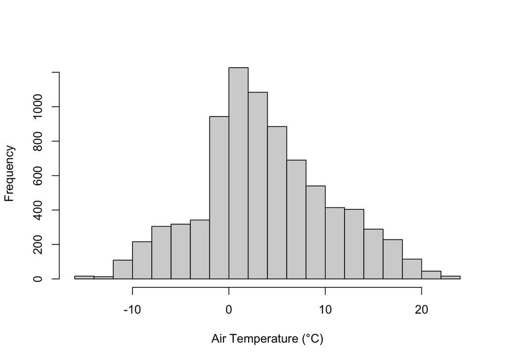

Figure 1: Air temperature (°C) measured at the Rice Rivers Center in Charles City County, Virginia during the first three months of 2014.

```r
rice$AirTemp <- (rice$AirTempF - 32) * 5/9
hist( rice$AirTemp,
      xlab="Air Temperature (°C)",
      main="")
```

### Select Operations

Which set of variables are we going to actually need?

- “Date”
- “Weekday”
- “Air Temperature”
- “Daytime”

```r
df <- rice[, c("Date", "Weekday", "AirTemp", "PAR")]
summary( df )
```

```
      Date                          Weekday        AirTemp
 Min.   :2014-01-01 00:00:00   Monday   :1152   Min.   :-15.6950
 1st Qu.:2014-01-22 08:22:30   Tuesday  :1152   1st Qu.: -0.2528
 Median :2014-02-12 16:45:00   Wednesday:1248   Median :  3.0222
 Mean   :2014-02-12 16:45:00   Thursday :1191   Mean   :  3.7751
 3rd Qu.:2014-03-06 01:07:30   Friday   :1152   3rd Qu.:  8.0056
 Max.   :2014-03-27 09:30:00   Saturday :1152   Max.   : 23.8167
                               Sunday   :1152
      PAR
 Min.   :   0.000
 1st Qu.:   0.000
 Median :   0.046
 Mean   : 241.984
 3rd Qu.: 337.900
 Max.   :1957.000
```

### Filter Operations

Which set of rows are we going to operate on? - “First Week of February” - “Daytime”

*Day Range*

```r
rice$DateTime[25]
```

```
[1] "1/1/2014 6:00:00 AM"
```

[output not shown]

```r
start_DateTime <- "2/1/2014 12:00:00 AM"
end_DateTime <- "2/7/2014 11:45:00 PM"

start <- parse_date_time( start_DateTime,
                          orders=format,
                          tz="EST")
end <- parse_date_time( end_DateTime,
                        orders=format,
                        tz="EST")

c( start, end )
```

```
[1] "2014-02-01 00:00:00 EST" "2014-02-07 23:45:00 EST"
```

```r
df1 <- df[ df$Date >= start & df$Date <= end, ]
summary( df1 )
```

```
      Date                          Weekday      AirTemp
 Min.   :2014-02-01 00:00:00   Monday   :96   Min.   :-3.594
 1st Qu.:2014-02-02 17:56:15   Tuesday  :96   1st Qu.: 1.106
 Median :2014-02-04 11:52:30   Wednesday:96   Median : 3.778
 Mean   :2014-02-04 11:52:30   Thursday :96   Mean   : 4.370
 3rd Qu.:2014-02-06 05:48:45   Friday   :96   3rd Qu.: 6.639
 Max.   :2014-02-07 23:45:00   Saturday :96   Max.   :16.550
                               Sunday   :96
      PAR
 Min.   :   0.000
 1st Qu.:   0.000
 Median :   0.044
 Mean   : 198.283
 3rd Qu.: 277.000
 Max.   :1365.000
```

*Daytime Filtering*

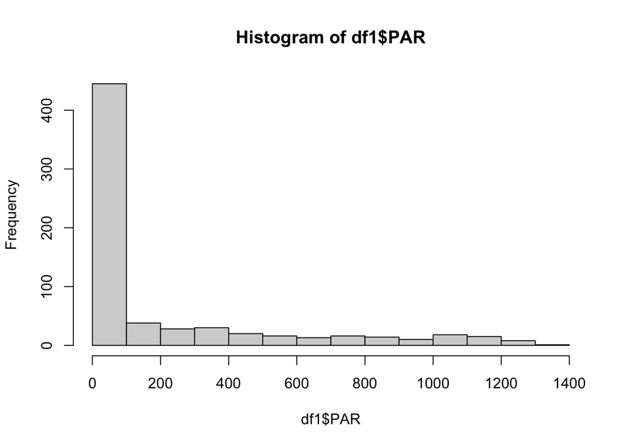

```r
hist( df1$PAR )
```

```r
df2 <- df1[ df1$PAR > 100,]
summary( df2 )
```

```
      Date                          Weekday      AirTemp            PAR
 Min.   :2014-02-01 09:00:00   Monday   :17   Min.   :-2.544   Min.   : 104.4
 1st Qu.:2014-02-02 14:07:30   Tuesday  :34   1st Qu.: 2.500   1st Qu.: 272.9
 Median :2014-02-04 14:45:00   Wednesday:30   Median : 5.356   Median : 486.2
 Mean   :2014-02-04 15:01:43   Thursday :36   Mean   : 5.732   Mean   : 573.0
 3rd Qu.:2014-02-06 12:52:30   Friday   :37   3rd Qu.: 7.900   3rd Qu.: 879.5
 Max.   :2014-02-07 18:00:00   Saturday :36   Max.   :16.550   Max.   :1365.0
                               Sunday   :37
```

```r
range( df2$Date[ df2$Weekday == "Monday"])
```

```
[1] "2014-02-03 11:15:00 EST" "2014-02-03 16:45:00 EST"
```

```r
df2 <- df1[ df1$PAR > 25,]
summary( df2 )
```

```
      Date                          Weekday      AirTemp
 Min.   :2014-02-01 08:30:00   Monday   :36   Min.   :-3.228
 1st Qu.:2014-02-02 15:37:30   Tuesday  :39   1st Qu.: 2.431
 Median :2014-02-04 13:30:00   Wednesday:38   Median : 5.306
 Mean   :2014-02-04 13:47:27   Thursday :40   Mean   : 5.470
 3rd Qu.:2014-02-06 11:22:30   Friday   :41   3rd Qu.: 7.381
 Max.   :2014-02-07 18:30:00   Saturday :40   Max.   :16.550
                               Sunday   :41
      PAR
 Min.   :  25.96
 1st Qu.: 154.80
 Median : 378.70
 Mean   : 483.61
 3rd Qu.: 775.35
 Max.   :1365.00
```

```r
range( df2$Date[ df2$Weekday == "Monday"])
```

```
[1] "2014-02-03 09:30:00 EST" "2014-02-03 18:15:00 EST"
```

Maybe?

*Maybe As Sunrise/Sunset*

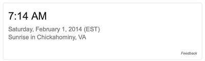

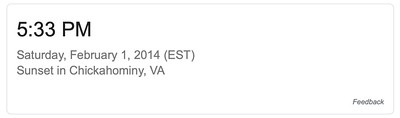

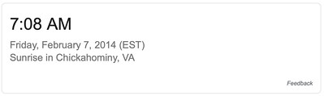

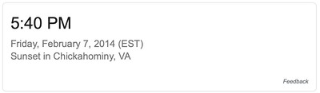

Look at only hours and minutes

```r
test <- df1[ df1$Weekday == "Monday",]
test$hour <- hour( test$Date )
test$minute <- minute( test$Date )
test
```

| Date | Weekday | AirTemp | PAR | hour | minute |
| --- | --- | --- | --- | --- | --- |
| 2014-02-03 00:00:00 | Monday | 9.244444 | 0.007 | 0 | 0 |
| 2014-02-03 00:15:00 | Monday | 8.044444 | 0.010 | 0 | 15 |
| 2014-02-03 00:30:00 | Monday | 6.777778 | 0.000 | 0 | 30 |
| 2014-02-03 00:45:00 | Monday | 7.050000 | 0.007 | 0 | 45 |
| 2014-02-03 01:00:00 | Monday | 7.400000 | 0.029 | 1 | 0 |
| 2014-02-03 01:15:00 | Monday | 7.738889 | 0.013 | 1 | 15 |
| 2014-02-03 01:30:00 | Monday | 7.838889 | 0.003 | 1 | 30 |
| 2014-02-03 01:45:00 | Monday | 9.150000 | 0.010 | 1 | 45 |
| 2014-02-03 02:00:00 | Monday | 9.933333 | 0.052 | 2 | 0 |
| 2014-02-03 02:15:00 | Monday | 9.627778 | 0.010 | 2 | 15 |

[output cut: 86 more lines]

```r
df3 <- df1
df3$Hour <- hour( df3$Date )
df3$Minute <- minute( df3$Date )
summary( df3 )
```

```
      Date                          Weekday      AirTemp
 Min.   :2014-02-01 00:00:00   Monday   :96   Min.   :-3.594
 1st Qu.:2014-02-02 17:56:15   Tuesday  :96   1st Qu.: 1.106
 Median :2014-02-04 11:52:30   Wednesday:96   Median : 3.778
 Mean   :2014-02-04 11:52:30   Thursday :96   Mean   : 4.370
 3rd Qu.:2014-02-06 05:48:45   Friday   :96   3rd Qu.: 6.639
 Max.   :2014-02-07 23:45:00   Saturday :96   Max.   :16.550
                               Sunday   :96
      PAR                Hour           Minute
 Min.   :   0.000   Min.   : 0.00   Min.   : 0.00
 1st Qu.:   0.000   1st Qu.: 5.75   1st Qu.:11.25
 Median :   0.044   Median :11.50   Median :22.50
 Mean   : 198.283   Mean   :11.50   Mean   :22.50
 3rd Qu.: 277.000   3rd Qu.:17.25   3rd Qu.:33.75
 Max.   :1365.000   Max.   :23.00   Max.   :45.00
```

```r
df4 <- df3[ df3$Hour >= 7 & df3$Minute >= 15,]
summary( df4 )
```

```
      Date                          Weekday      AirTemp
 Min.   :2014-02-01 07:15:00   Monday   :51   Min.   :-3.594
 1st Qu.:2014-02-02 19:45:00   Tuesday  :51   1st Qu.: 1.606
 Median :2014-02-04 15:30:00   Wednesday:51   Median : 4.811
 Mean   :2014-02-04 15:30:00   Thursday :51   Mean   : 5.026
 3rd Qu.:2014-02-06 11:15:00   Friday   :51   3rd Qu.: 6.944
 Max.   :2014-02-07 23:45:00   Saturday :51   Max.   :16.550
                               Sunday   :51
      PAR                Hour        Minute
 Min.   :   0.000   Min.   : 7   Min.   :15
 1st Qu.:   0.007   1st Qu.:11   1st Qu.:15
 Median :  82.400   Median :15   Median :30
 Mean   : 279.134   Mean   :15   Mean   :30
 3rd Qu.: 449.500   3rd Qu.:19   3rd Qu.:45
 Max.   :1297.000   Max.   :23   Max.   :45
```

```r
df5 <- df4[ df4$Hour <= 17 & df4$Minute <=30,  ]
summary( df5 )
```

```
      Date                          Weekday      AirTemp            PAR
 Min.   :2014-02-01 07:15:00   Monday   :22   Min.   :-3.211   Min.   :   0.0
 1st Qu.:2014-02-02 15:18:45   Tuesday  :22   1st Qu.: 1.431   1st Qu.:  89.8
 Median :2014-02-04 12:22:30   Wednesday:22   Median : 4.850   Median : 325.1
 Mean   :2014-02-04 12:22:30   Thursday :22   Mean   : 4.775   Mean   : 427.3
 3rd Qu.:2014-02-06 09:26:15   Friday   :22   3rd Qu.: 6.808   3rd Qu.: 731.9
 Max.   :2014-02-07 17:30:00   Saturday :22   Max.   :16.550   Max.   :1297.0
                               Sunday   :22
      Hour        Minute
 Min.   : 7   Min.   :15.0
 1st Qu.: 9   1st Qu.:15.0
 Median :12   Median :22.5
 Mean   :12   Mean   :22.5
 3rd Qu.:15   3rd Qu.:30.0
 Max.   :17   Max.   :30.0
```

```r
df5[21:30,]
```

[output not shown]

*Select - Again*

```r
df6 <- df5[ , c("Date","Weekday","AirTemp")]
```

### Summarize - Tabular

Create a table that has:  
- Date as row  
- Minimum, Mean, & Maximum air temperature as columns

```r
day( df6$Date )
```

```
  [1] 1 1 1 1 1 1 1 1 1 1 1 1 1 1 1 1 1 1 1 1 1 1 2 2 2 2 2 2 2 2 2 2 2 2 2 2 2
 [38] 2 2 2 2 2 2 2 3 3 3 3 3 3 3 3 3 3 3 3 3 3 3 3 3 3 3 3 3 3 4 4 4 4 4 4 4 4
 [75] 4 4 4 4 4 4 4 4 4 4 4 4 4 4 5 5 5 5 5 5 5 5 5 5 5 5 5 5 5 5 5 5 5 5 5 5 6
[112] 6 6 6 6 6 6 6 6 6 6 6 6 6 6 6 6 6 6 6 6 6 7 7 7 7 7 7 7 7 7 7 7 7 7 7 7 7
[149] 7 7 7 7 7 7
```

```r
minTemp <- by( df6$AirTemp, day( df6$Date  ), min )
meanTemp <- by( df6$AirTemp, day( df6$Date  ), mean )
maxTemp <- by( df6$AirTemp, day( df6$Date  ), max )
df.table <- data.frame( Minimum = as.numeric( minTemp ),
                        Average = as.numeric( meanTemp),
                        Maximum = as.numeric( maxTemp ) )
df.table
```

| Minimum | Average | Maximum |
| --- | --- | --- |
| -3.2111111 | 5.143182 | 11.383333 |
| 5.9722222 | 11.197222 | 16.550000 |
| 4.4833333 | 5.601010 | 7.244444 |
| -0.5055556 | 3.268939 | 5.550000 |
| 0.7777778 | 3.425000 | 8.644444 |
| -0.6166667 | 1.162374 | 3.061111 |
| -0.8000000 | 3.629293 | 7.677778 |

```r
df.table$Date <- mdy( paste( "2",1:7,"2014", sep="/") )
df.table$Weekday <- weekdays( df.table$Date )
df.table
```

| Minimum | Average | Maximum | Date | Weekday |
| --- | --- | --- | --- | --- |
| -3.2111111 | 5.143182 | 11.383333 | 2014-02-01 | Saturday |
| 5.9722222 | 11.197222 | 16.550000 | 2014-02-02 | Sunday |
| 4.4833333 | 5.601010 | 7.244444 | 2014-02-03 | Monday |
| -0.5055556 | 3.268939 | 5.550000 | 2014-02-04 | Tuesday |
| 0.7777778 | 3.425000 | 8.644444 | 2014-02-05 | Wednesday |
| -0.6166667 | 1.162374 | 3.061111 | 2014-02-06 | Thursday |
| -0.8000000 | 3.629293 | 7.677778 | 2014-02-07 | Friday |

*Select to Rearrange*

```r
df.table1 <- df.table[ , c(5,1,2,3)]
```

*Table Output*

```r
library( knitr )
library( kableExtra )
t <- kable( df.table1,
            caption="Table 1: Temperature Ranges for daytime air temperature for the first week of February, 2014 at the Rice Rivers Center in Charles City County, Virginia.")
kable_styling( t )
```

Table 1: Temperature Ranges for daytime air temperature for the first week of February, 2014 at the Rice Rivers Center in Charles City County, Virginia.

| Weekday | Minimum | Average | Maximum |
| --- | --- | --- | --- |
| Saturday | -3.2111111 | 5.143182 | 11.383333 |
| Sunday | 5.9722222 | 11.197222 | 16.550000 |
| Monday | 4.4833333 | 5.601010 | 7.244444 |
| Tuesday | -0.5055556 | 3.268939 | 5.550000 |
| Wednesday | 0.7777778 | 3.425000 | 8.644444 |
| Thursday | -0.6166667 | 1.162374 | 3.061111 |
| Friday | -0.8000000 | 3.629293 | 7.677778 |

### Summarize - Graphically

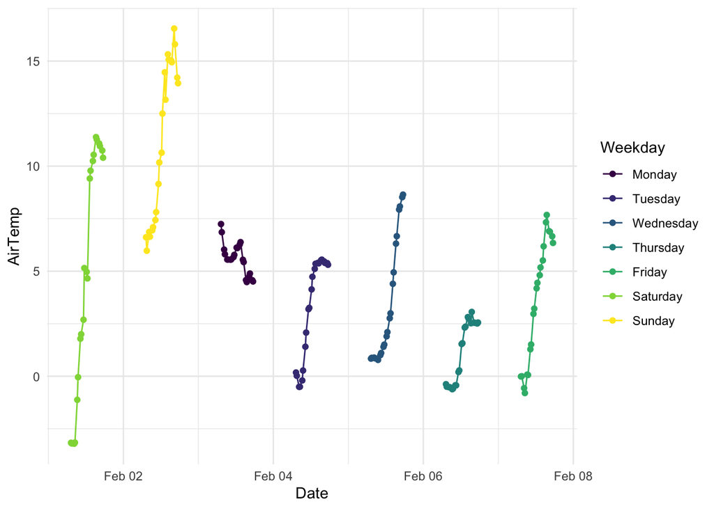

```r
library( ggplot2 )
ggplot( df6, aes(x=Date, y=AirTemp, color=Weekday) ) +
  geom_line() +
  geom_point() +
  theme_minimal()
```

Challenges associated with this approach

- Lots of steps
- Step divided into many chunks
- Making of lots of data frames to hold intermediate options

```r
ls()
```

```
 [1] "days"           "df"             "df.table"       "df.table1"
 [5] "df1"            "df2"            "df3"            "df4"
 [9] "df5"            "df6"            "end"            "end_DateTime"
[13] "format"         "maxTemp"        "meanTemp"       "minTemp"
[17] "rice"           "start"          "start_DateTime" "t"
[21] "test"           "url"
```

[output not shown]

[figure not shown]

# Tidyverse

OK, so let’s jump in.

> GGPlot is to built-in graphics as ____________ is to data workflows.
> 1. Tidyverse
> 2. Tidyverse
> 3. Tidyverse, or
> 4. Tidyverse

Tidyverse is a collection of libraries.

```r
library( tidyverse )
```

[figure not shown]

And one of the most important things that it includes is the notion of Pipes.

```r
df2 <- SOME_OPERATION( df1 )
df3 <- SOME_OTHER_OPERATION( df2 )
df4 <- A_THIRD_OPERATION( df3 )
ggplot( df4, aes(x=...,y=...) ) + geom_point()
```

This pattern of operations is very common.

*The output of one function becomes the input of another one*

Insted of re-assigning all these variables, we can take a shortcut using the pipe function (it is defined in the `magrittr` library which is part of the `tidyverse`), denoted as `%>%`

```r
df1 %>%
  SOME_OPERATION() %>%
  SOME_OTHER_OPERATION() %>%
  A_THIRD_OPERATION %>%
  ggplot( aes(x=...,y=...) ) + geom_point()
```

Here is a pipe of the `df.table` data.frame into the `kable` and `kableExtra` functions.

```r
df.table1 %>%
  kable( format="html", digits = 2 ) %>%
  kable_paper() %>%
  column_spec( 2, color=ifelse( df.table1$Minimum < 0, "blue", ""))
```

| Weekday | Minimum | Average | Maximum |
| --- | --- | --- | --- |
| Saturday | -3.21 | 5.14 | 11.38 |
| Sunday | 5.97 | 11.20 | 16.55 |
| Monday | 4.48 | 5.60 | 7.24 |
| Tuesday | -0.51 | 3.27 | 5.55 |
| Wednesday | 0.78 | 3.43 | 8.64 |
| Thursday | -0.62 | 1.16 | 3.06 |
| Friday | -0.80 | 3.63 | 7.68 |

**NOTE:** It is implicitly passing along the output of the previous item (on the left of the pipe) to serve as the input to the next item (on the right of the pipe). So there is no need to redefine `data.frame` objects OR put the names of the data.frames into the function parentheses.

Same for `ggplot()`

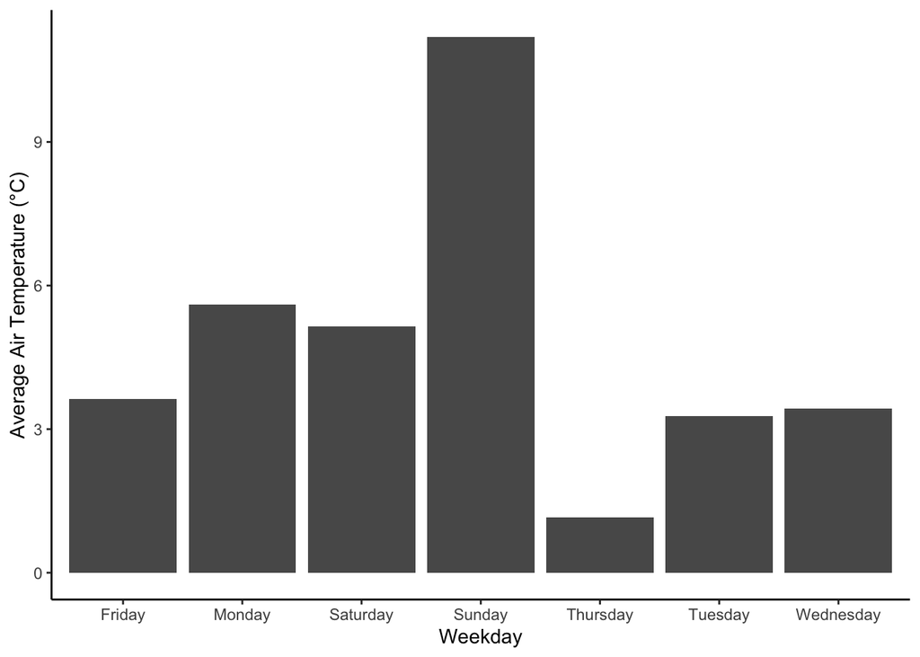

```r
df.table1 %>%
  ggplot( aes(x=Weekday,y=Average) ) +
  geom_col() +
  ylab("Average Air Temperature (°C)") +
  theme_classic()
```

OK, so now let’s get back into the *verbs* of data analysis. The reason I used these particular keywords is that hey are identical to the function names used in `dplyr` (the data pliars library in `tidyverse`).

- Select is done using function `select()`
- Filter is done using function `filter()`
- Mutate is done using function `mutate()`
- Arrange is done using function `arrange()`
- Group is done using function `group_by()`
- Summarize is done using function `summarize()`

In what follows, I will redo the stuff from above showing how we can incorporate both the pipe function as well as these *verb* functions. Let’s first reload the data from scratch.

```r
rice <- read_csv( url )
```

### Tidy Select

Select allows us to grab the column by the name in the `data.frame`.

```r
rice %>%
  select( DateTime, AirTempF ) %>%
  head()
```

| DateTime | AirTempF |
| --- | --- |
| 1/1/2014 12:00:00 AM | 30.99 |
| 1/1/2014 12:15:00 AM | 30.72 |
| 1/1/2014 12:30:00 AM | 31.22 |
| 1/1/2014 12:45:00 AM | 30.54 |
| 1/1/2014 1:00:00 AM | 30.93 |
| 1/1/2014 1:15:00 AM | 30.61 |

To drop columns, you can use the name of the column with a negative sign prepended on it.

```r
rice %>%
  select( -RecordID, -SpCond_mScm, -PH_mv, -Depth_ft, -SurfaceWaterElev_m_levelNad83m ) %>%
  names()
```

```
 [1] "DateTime"      "PAR"           "WindSpeed_mph" "WindDir"
 [5] "AirTempF"      "RelHumidity"   "BP_HG"         "Rain_in"
 [9] "H2O_TempC"     "Salinity_ppt"  "PH"            "Turbidity_ntu"
[13] "Chla_ugl"      "BGAPC_CML"     "BGAPC_rfu"     "ODO_sat"
[17] "ODO_mgl"       "Depth_m"
```

[output not shown]

You can also use it to re-arrange the column order (and because we are lazy, we have the `everything()` function to say ’well, everything else that I haven’t already identified).

```r
rice %>%
  select( AirTempF, WindDir, Rain_in, everything() ) %>%
  names()
```

```
 [1] "AirTempF"                       "WindDir"
 [3] "Rain_in"                        "DateTime"
 [5] "RecordID"                       "PAR"
 [7] "WindSpeed_mph"                  "RelHumidity"
 [9] "BP_HG"                          "H2O_TempC"
[11] "SpCond_mScm"                    "Salinity_ppt"
[13] "PH"                             "PH_mv"
[15] "Turbidity_ntu"                  "Chla_ugl"
[17] "BGAPC_CML"                      "BGAPC_rfu"
[19] "ODO_sat"                        "ODO_mgl"
[21] "Depth_ft"                       "Depth_m"
[23] "SurfaceWaterElev_m_levelNad83m"
```

[output not shown]

### Filter

Filter allows us to select the rows by attributes of the data *withing* the table itself.

```r
rice %>%
  filter( AirTempF < 32 ) %>%
  head()
```

| DateTime | RecordID | PAR | WindSpeed_mph | WindDir | AirTempF | RelHumidity | BP_HG | Rain_in | H2O_TempC | SpCond_mScm | Salinity_ppt | PH | PH_mv | Turbidity_ntu | Chla_ugl | BGAPC_CML | BGAPC_rfu | ODO_sat | ODO_mgl | Depth_ft | Depth_m | SurfaceWaterElev_m_levelNad83m |
| --- | --- | --- | --- | --- | --- | --- | --- | --- | --- | --- | --- | --- | --- | --- | --- | --- | --- | --- | --- | --- | --- | --- |
| 1/1/2014 12:00:00 AM | 43816 | 0 | 3.870 | 14.58 | 30.99 | 80.5 | 30.30 | 0 | 6.44 | 0.130 | 0.06 | 7.22 | -10.9 | 20.3 | 3.7 | 717 | 0.4 | 96.3 | 11.85 | 15.324 | 4.670755 | -31.55924 |
| 1/1/2014 12:15:00 AM | 43817 | 0 | 4.787 | 18.53 | 30.72 | 82.1 | 30.30 | 0 | 6.49 | 0.137 | 0.06 | 7.52 | -26.8 | 21.8 | 3.2 | 736 | 0.4 | 99.9 | 12.28 | 15.512 | 4.728058 | -31.50194 |
| 1/1/2014 12:30:00 AM | 43818 | 0 | 3.614 | 16.16 | 31.22 | 81.9 | 30.29 | 0 | 6.38 | 0.134 | 0.06 | 7.53 | -27.4 | 21.8 | 3.6 | 565 | 0.3 | 100.6 | 12.40 | 15.695 | 4.783836 | -31.44616 |
| 1/1/2014 12:45:00 AM | 43819 | 0 | 2.986 | 11.47 | 30.54 | 83.0 | 30.30 | 0 | 6.42 | 0.136 | 0.06 | 7.53 | -27.4 | 21.4 | 3.5 | 894 | 0.5 | 100.3 | 12.35 | 15.844 | 4.829251 | -31.40075 |
| 1/1/2014 1:00:00 AM | 43820 | 0 | 3.522 | 11.31 | 30.93 | 81.8 | 30.30 | 0 | 6.35 | 0.132 | 0.06 | 7.55 | -28.3 | 22.0 | 3.4 | 861 | 0.4 | 101.4 | 12.51 | 15.981 | 4.871009 | -31.35899 |
| 1/1/2014 1:15:00 AM | 43821 | 0 | 3.827 | 20.02 | 30.61 | 82.8 | 30.30 | 0 | 6.31 | 0.130 | 0.06 | 7.56 | -29.1 | 21.9 | 3.5 | 625 | 0.3 | 102.1 | 12.61 | 16.099 | 4.906976 | -31.32302 |

### Mutate

Mutate allows us to change the columns of the data, either *in-place* (e.g., replacing the original column) or by adding columns to it.

```r
rice %>%
  mutate( Date = parse_date_time( DateTime,
                                  orders=format,
                                  tz="EST") ) %>%
  mutate( Weekday = factor( weekdays( Date ),
                            ordered=TRUE,
                            levels=days) ) %>%
  mutate( AirTemp = (AirTempF - 32) * 5/9 ) %>%
  select( Date, Weekday, AirTemp) %>%
  summary()
```

```
      Date                          Weekday        AirTemp
 Min.   :2014-01-01 00:00:00   Monday   :1152   Min.   :-15.6950
 1st Qu.:2014-01-22 08:22:30   Tuesday  :1152   1st Qu.: -0.2528
 Median :2014-02-12 16:45:00   Wednesday:1248   Median :  3.0222
 Mean   :2014-02-12 16:45:00   Thursday :1191   Mean   :  3.7751
 3rd Qu.:2014-03-06 01:07:30   Friday   :1152   3rd Qu.:  8.0056
 Max.   :2014-03-27 09:30:00   Saturday :1152   Max.   : 23.8167
                               Sunday   :1152
```

Note: I had to do separate `mutate()` events here to get the weekday, the first to make it a Date column and the second to use that to make another column for weekdays.

It is also possible to use use this to make more readable column names (“Look ma! No `ylab` needed!”). You just have to use the back tick characters to surround the new data column name.

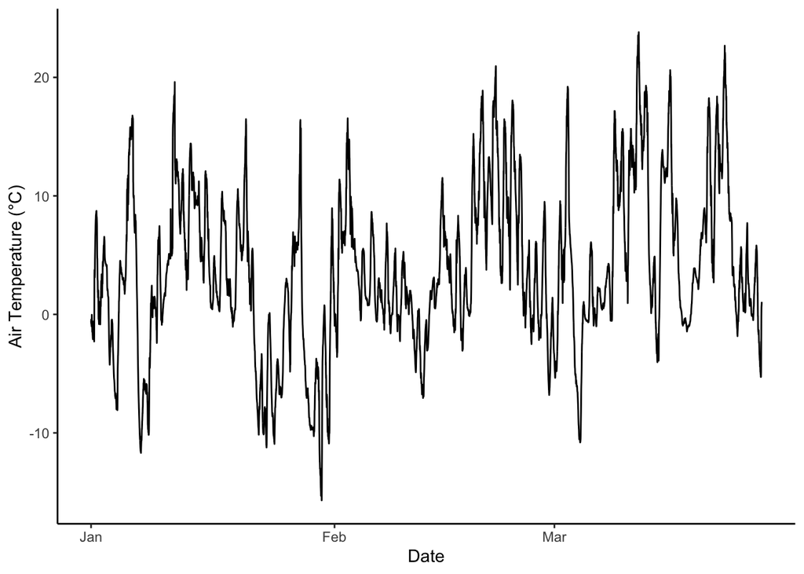

```r
rice %>%
  mutate( Date = parse_date_time( DateTime,
                                  orders=format,
                                  tz="EST") ) %>%
  mutate( `Air Temperature (°C)` = (AirTempF - 32) * 5/9 ) %>%
  select( Date, `Air Temperature (°C)`) %>%
  ggplot( aes( x = Date, y = `Air Temperature (°C)`) ) +
  geom_line() +
  theme_classic()
```

### Arrange

Arrange is used to sort the data.

```r
rice %>%
  arrange( AirTempF ) %>%
  select( DateTime, AirTempF ) %>%
  head()
```

| DateTime | AirTempF |
| --- | --- |
| 1/30/2014 8:45:00 AM | 3.749 |
| 1/30/2014 9:00:00 AM | 3.820 |
| 1/30/2014 6:45:00 AM | 4.434 |
| 1/30/2014 7:00:00 AM | 4.664 |
| 1/30/2014 8:30:00 AM | 4.926 |
| 1/30/2014 6:30:00 AM | 5.021 |

Reversing it (e.g., in descending order) is done by prepending a negative sign.

```r
rice %>%
  arrange( -AirTempF ) %>%
  select( DateTime, AirTempF ) %>%
  head()
```

| DateTime | AirTempF |
| --- | --- |
| 3/11/2014 5:45:00 PM | 74.87 |
| 3/11/2014 5:30:00 PM | 74.58 |
| 3/11/2014 3:45:00 PM | 74.38 |
| 3/11/2014 6:00:00 PM | 74.13 |
| 3/11/2014 4:00:00 PM | 73.45 |
| 3/11/2014 4:45:00 PM | 73.05 |

### Group

So here is where we start getting to have some fun. The `group_by` function partitions the data and is used to create content for the subsequent steps. Think about the various ways we have used `by()` thus far. For these, we had to:

1. Identify a column to use as a grouping.
2. Apply some function to those individual groups.

Same things here. It is just that being *grouped* gives the `data.frame` an extra added attribute. Compare the `class` object for the rice `data.frame`.

```r
class( rice )
```

```
[1] "spec_tbl_df" "tbl_df"      "tbl"         "data.frame"
```

[output not shown]

to what it is after I make weekdays and then `group-by()` that column.

```r
rice %>%
  mutate( Date = parse_date_time( DateTime,
                                  orders=format,
                                  tz="EST") ) %>%
  mutate( Weekday = factor( weekdays( Date ),
                            ordered=TRUE,
                            levels=days) ) %>%
  group_by( Weekday ) %>%
  class()
```

```
[1] "grouped_df" "tbl_df"     "tbl"        "data.frame"
```

[output not shown]

It is the `grouped_df` that is used by things like `summarize()` when it does its operations. It will make more sense in a minute.

### Summarize

Summarize allows you to take a bit of the original data and then perform operations on it to create a new `data.frame`.

Here is how we could get total amount of rain for each weekday in the entire data set from the raw data as a single inquiry.

```r
rice %>%
  mutate( Date = parse_date_time( DateTime,
                                  orders=format,
                                  tz="EST") ) %>%
  mutate( Weekday = factor( weekdays( Date ),
                            ordered=TRUE,
                            levels=days) ) %>%
  group_by( Weekday ) %>%
  summarize( Rain = sum( Rain_in ) , .groups = 'drop')
```

| Weekday | Rain |
| --- | --- |
| Monday | 1.963 |
| Tuesday | 1.312 |
| Wednesday | 0.327 |
| Thursday | 1.207 |
| Friday | 0.800 |
| Saturday | 1.032 |
| Sunday | 0.256 |

The only columns in the `group_by` and `summarize` statements will be kept and provided as output.